# R in the Classroom - I

Danny Kaplan  
NIMBIOS Computing in the Cloud Workshop

### To Do:

1. Set up the NIMBIOS package: Done
2. Add a scaffold file to NIMBIOS. Maybe a scaffold function?

### Tutorial about Teaching?

> A tutorial is … more *interactive* and specific than a book or a lecture; a tutorial seeks to *teach by example* and supply the information to complete a certain task. — [Wikipedia](http://en.wikipedia.org/wiki/Tutorial)

### Plan:

- Show some resources for teaching.
  - Today: Introductory students.
    - Start to develop a short lesson using these resources
  - Tomorrow: Several possiibilities
    - Writing a lesson on one of the other tutorials
    - Data wrangling? Teaching programming in R?

### Outline

### Some resources for teaching with R

RStudio, `mosaic`, editor and Rmd.

### Some principles of teaching with computation

These apply to many different software packages.

### Illustrations of applying those principles with R

Using mainly `mosaic` and Rmd

### RStudio

### Integrated Development Environment (IDE) for R

- Desktop and server/cloud version
- **Conveniences**: Workspace viewer, command history, figure export, package installation, help
- **Big stuff** (to me):
  - Connects an editor to R and support for producing documents within the IDE.
    - \( \LaTeX \) is there, but that's too hard for intro students
    - Markdown. Compiles to HTML, PDF, Word
  - Project organization and Collaboration support for instructors (or students)

### RStudio: Use the Server for Students

### Pros

- Very little startup/installation hassle.
- Students can access their sessions from any computer. They don't have to pay attention to `save()`ing, etc.
- Instructors can access student sessions. (This feature can be improved.)

### Cons

- Speed (?)
- Students can get confused about file location (“my computer?”).  
  To avoid such confusion, have students do everything from the server, not move back and forth between server and desktop. More details later.

### Markdown and Editing

Markdown is a straightforward markup language for producing documents quickly.

- Simple syntax (unlike \( \LaTeX \))
- Compiles to HTML (or PDF or Word).
- Can include straight HTML (e.g. iframes, video)

The RStudio editor provides easy facilities for working with Markdown and integrating it with R. (But doing this doesn't require RStudio.)

### For instructors

You are generally switching among contexts: teach class A, research project B, revise paper C, teach class D, test out epiphany E

**Projects** in RStudio are a simple way to keep these contexts distinct and organized, and to be able to switch back and forth. Documents being edited stay open.

Other useful tools for instructors:

- Git and GitHub for collaborating on projects and publishing
- R packages

### Interaction: Write a Biography in Markdown

It could be you, a historic figure, etc.

Include:

- sections and subsections
- bulleted and numbered lists
- links and images (note: these go together)

### How to ...

## In RStudio

1. Open a document using `New File/R Markdown`
2. Name and save the file.
3. Press `Knit HTML` button

## In generic R

One time: Install `knitr` package

1. Create and save a file. `.Rmd` is a nice suffix.
2. From the R session, use the `knit2html()` function to compile to HTML, e.g.

```r
knit2html('GeorgeWashington.Rmd')
```

### The `mosaic` package

Available on CRAN: Install in the usual way, e.g.

```r
install.packages('mosaic')
```

- Attempts to provide a coherent and unified set of commands, to make it easier for beginning students to use R.
- Stays close to standard R whenever possible
- Used for both statistics and calculus

Example:

```r
mean( height ~ sex, data=Galton )
```

Created by DTK, Randall Pruim (Calvin College), Nick Horton (Amherst College)

### Some Principles for Teaching with R

### Principle:

An idea that forms the basis of something

### Reflection:

A thought, idea, or opinion formed or a remark made as a result of meditation

## Watch out!

These are not a self-consistent and complete set of statements.

### The Principles in Brief

- Keep it simple and consistent for your students.
- Teach one thing at a time (or, at least, not everything at once).
- Support collaboration.
- Illustrate a professional workflow.
- Don't code, Express!
- Provide immediate gratification/confidence when starting out every day.
- Give students a working scaffold/template.
- Make the technology central to how and what you teach.
- Build on what students already know.

### As Simple as Possible

> Man soll die Dinge so einfach machen wie möglich - aber nicht einfacher.  
> Everything should be made as simple as possible, but not simpler. — A. Einstein

### Keep it Simple and Consistent

- Accessing data should not be esoteric or a labor.
  - Let students refer to data just by name. e.g. `Galton`
  - Have a repository.
  - Suggestion: Develop a package for each course to hold data and other files, and simple functions for accessing them.

`mosaic` syntax: graphics, basic descriptive states, modeling.

- formulas
- `data=`

### Some Tasks for You

1. Calculate the mean of a variable (say, `height` in `Galton`)
2. Calculate groupwise means (e.g., `height` broken down by `sex` )
3. Find the residuals from groupwise means.
4. Find the correlation between two variables (e.g. `mother` and `father`)
5. Find R<sup>2</sup> of a model

### Functions that operate in a consistent way

`mosaic` extends some existing functions. Look at `mean()`.

```r
mean( height ~ sex, data=Galton)
```

```
    F     M
64.11 69.23
```

### It's the same syntax as other operations

```r
bwplot( height ~ sex, data=Galton )
xyplot( height ~ father, data=Galton )
lm( height ~ father, data=Galton )
```

### Means as models

Mean is so widely used, we didn't want to break it. So, `mm()` for modeling with groupwise means.

```r
mm( height ~ sex, data=Galton )
```

```
Groupwise Model Call:
height ~ sex

Coefficients:
   F     M
64.1  69.2
```

Try `fitted()`, `resid()`, `confint()`, `rsquared()`

### Build on What Students Already Know

Many know about functions and their graphs.

```r
mod <- lm( height ~ mother * sex, data=Galton)
f <- makeFun(mod)
f(mother=65,sex='F') - f(mother=64,sex='F')
```

```
     1
0.3266
```

### Graphing functions

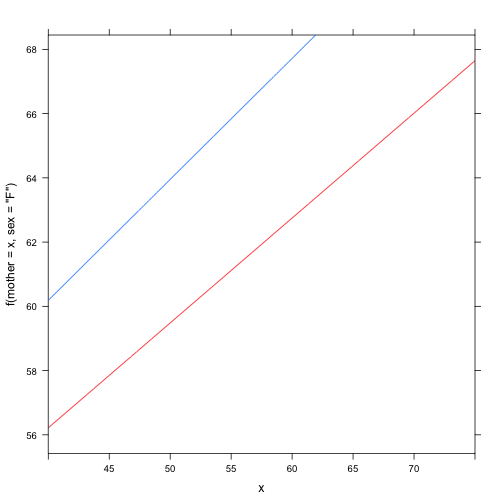

```r
plotFun( f(mother=x, sex='F') ~ x, x.lim=c(40,75),
         col='red')
plotFun( f(mother=x, sex='M') ~ x, add=TRUE)
```

### Calculus in R

At Macalester, we use R in the first calculus course (which is multivariable with a modeling theme).

```r
D( sqrt(x*sin(x^2)) ~ x )
```

```
function (x)
0.5 * ((sin(x^2) + x * (cos(x^2) * (2 * x))) * (x * sin(x^2))^-0.5)
```

```r
antiD( 1/x ~ x )
```

```
function (x, C = 0)
1 * log((x)) + C
```

Also: model fitting (with nonlinear parameters), differential equations, units and dimensions, …

### Integration is Symbolic and Numeric

Symbolic for the easy ones. Numeric otherwise.

But both return a function.

```r
f <- antiD( x*sin(x) ~ x)
f
```

```
function (x, C = 0)
{
    numerical_integration(.newf, .wrt, as.list(match.call())[-1],
        formals(), from, ciName = intC, .tol)
}
<environment: 0x1084dda38>
```

```r
f(3) - f(0)
```

```
[1] 3.111
```

### Sharing and Distributing Files

- Simplest for students > Put your data in a package
- Simplest for instructor: > Put fixed data on website and provide URL
- Hardest for Everybody > Students copying files onto their own machines.
- for dynamic data, use collaborative editing as with Google Docs
- Collaborative Editing

### Don't Teach Everything at Once

If you're teaching data cleaning or wrangling, give students the raw data and have them produce a new set of data.

If you're teaching statistics or the content of the data, give them clean data in an easy to use form.

> You can always say later, “Here's where that simple dataset came from.”

### Two things at once: Example

- Data management and cleaning with nhanesOriginal
  - Everything is quantitative
  - Must constantly refer to the codebook
  - Have to convert some variables to categorical for even simple tasks.
- NHANES cleaned up

### Support collaboration

Something of a contradiction:

- Ask students to work in teams on technical matters and reports.
- Provide them with **no support** specifically oriented to computing.

You can't use Word very well for reporting on R.  
A Google Doc is much like Word.

### What tools do you use for supporting collaboration?

### Collaborative Editing with Google Docs

### How to create a spreadsheet for editing

- create, publish, provide link for editing
- provide link to access as CSV

### Bring the edited spreadsheet back to R

- with `mosaic` package, `fetchGoogle( link )`

> Example: Bird species names from Macalester's Ordway Conservation Area logs from the 1970s and 80s `Resources/NamesForCleaning.csv`.

Google broke my system: Use the old stuff. I'll try to figure something out with RXML or RJSONIO, or RGoogleDocs.

- Original birds [for editing](https://docs.google.com/spreadsheet/ccc?key=0Av2C2RiwUxpVdFlPWUp6NERSQzhld3o4QklQd1p6d2c&usp=sharing) and [as CSV](https://docs.google.com/spreadsheet/pub?key=0Av2C2RiwUxpVdFlPWUp6NERSQzhld3o4QklQd1p6d2c&single=true&gid=0&output=csv)

### Collaborative Editing of Documents

Packages are straightforward to write and install.

```r
install_github('dtkaplan/NIMBIOS')
```

This package has an example of a collaborative editor:

```r
f <- collaborate(doc="NIMBIOS")
f('edit')
```

Any time you want to bring this into R:

```r
f('capture')
```

### Make the technology central to how and what you teach.

Least squares fitting:

```r
mod1 <- mm( height ~ sex, data=Galton)
sum( resid(mod1)^2 )
```

```
[1] 5640
```

```r
mod2 <- mm( height ~ sex, data=Galton, fun=median )
sum( resid(mod2)^2 )
```

```
[1] 5646
```

### Or let students make up functions

A template for the model:

```r
myf <- makeFun( ifelse(sex=='F', 64, 69)~sex)
myf(sex='M')
```

```
[1] 69
```

Look at the residuals:

```r
resids <- with(Galton, height - myf(sex))
sum( resids^2 )
```

```
[1] 5670
```

### How and What You Teach: Inference

Are you using paper-and-pencil techniques but having the students save time and avoid error by doing them on the computer, e.g.

- z-test, p-test, t-test
- ANOVA

The statistical concepts are easier to understand if they are presented in their essence: the 3 Rs of statistical inference.

### Randomize, Repeat, Reject

### Randomize

- `resample()`, `shuffle()` and `rand()`

## Sampling Distributions

```r
mean( height ~ sex, data=resample(Galton) )
```

```
    F     M
64.10 69.33
```

```r
lm( height ~ father, data=resample(Galton) )
```

```
(Intercept)      father
     41.507       0.365
```

### Shuffle

## Null Hypothesis

```r
mean( shuffle(height) ~ sex, data=Galton )
```

```
    F     M
66.73 66.79
```

```r
lm( shuffle(height) ~ father, data=Galton )
```

```
(Intercept)      father
   62.03259     0.06829
```

### ANOVA

ANOVA is not essentially about within-groups and between-groups variability.

It's about whether added terms in a model pull their weight:

```r
mod1 <- lm( height ~ sex,
            data=Galton )
mod2 <- lm( height ~ sex + family,
            data=Galton )
```

`mod2` includes a categorical variable giving the family.

```
rsquared( mod1 )
rsquared( mod2 )
```

### ANOVA (continued)

```r
length(coef(mod2))
```

```
[1] 198
```

```r
rsquared(mod2)
```

```
[1] 0.7666
```

```r
rsquared(lm( height ~ sex +
               rand(196), data=Galton ) )
```

```
[1] 0.6133
```

### Don't code, Express!

To continue with the ANOVA example: generate a large number of the randomized model and compare with the value from `mod2`.

Loops? Accumulators? Application to vectors, or is it lists?

Just do it!

```r
do(5)*rsquared(lm( height ~ sex + rand(196), data=Galton ) )
```

```
  result
1 0.6092
2 0.6058
3 0.6242
4 0.6129
5 0.6077
```

```r
samps <- do(200)*rsquared(lm(height ~ sex + rand(196), data=Galton ))
```

### Don't Code! (2)

## Avoid distracting details:

- Standard plots are generally good enough. You don't need to elaborate.
- Don't force students to read code they won't understand.
- If your project needs code, put it in a function and distribute the function via your course package.

### And reject?

Use the test statistic directly:

```r
pdata( .73, ~result, data=samps)
```

```
[1] 1
```

### Or, using normal theory:

```r
anova( mod1, mod2 )
```

```
Analysis of Variance Table

Model 1: height ~ sex
Model 2: height ~ sex + family
  Res.Df  RSS  Df Sum of Sq    F Pr(>F)
1    896 5640
2    700 2688 196      2953 3.92 <2e-16 ***
---
Signif. codes:  0 '***' 0.001 '**' 0.01 '*' 0.05 '.' 0.1 ' ' 1
```

### Give students a working scaffold/template.

Example: I often start with a graph-reading exercise. Partly, this is to get students to realize that even if they think they know, they often do not.

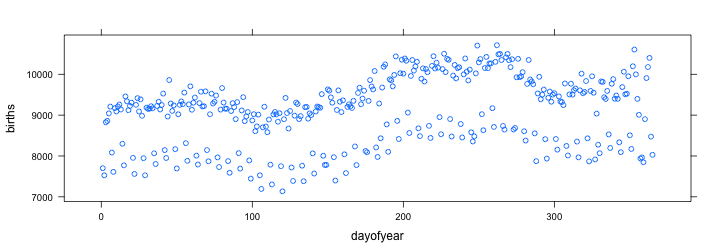

### Provide immediate confidence when starting out every day.

### Not “R has a steep learning curve”

Your scaffolds can do this. Make them attractive.

### Illustrate a professional workflow.

- Document your work.
- Write coherent explanations.
- Don't alter your data, except when documented and reversible
- Write and provide your own notes this way

> > > This is where R/Markdown is fantastic.

### Don't Code in Front of Students

Code examples:

- loops
- accumulators
- conditionals
- indexing brackets. Use `subset()`, `transform()`, …

Example: Bootstrapping

`do()` and `resample()` functions

Example: Hypothesis Testing

### mPlot()

We need to document, which implies code. But the code for graphics gets difficult, and it's hard for students to play with the possibilities.

Generates the code needed to recreate the plot. (`mBar()` to come.)

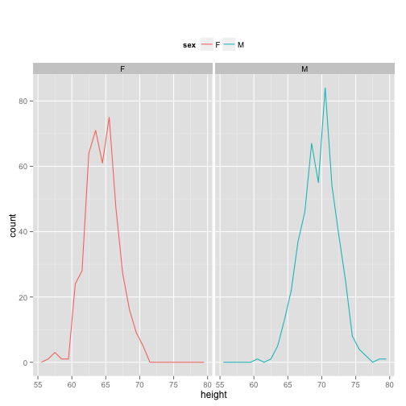

```r
mScatter( Galton )
mPlot( Galton, default='density')
```

### Activities

Get started on these. See what progress you can make and then we'll return to them tomorrow.

- A lesson about confidence intervals. Here's a population: Ten Mile Race
- Show that even random junk contributes to R<sup>2.</sup> Have the students discover the relationship.
- Distribution of the F statistic under the Null
- A logistic regression lesson. When you can just use `lm()`, when `glm()` is important. Example: Cardiac death and smoking in the NHANES-III data. Or: why and when when modeling yes/no outcomes is logistic regression more appropriate than linear modeling?
- Something that relates to a dataset of interest to you in your teaching.